# 606 presentation - probability model

2/27/2020

## Problem - Create A Probability Model

**4.35 Roulette winnings.** In the game of roulette, a wheel is spun and you place bets on where it will stop. One popular bet is that it will stop on a red slot; such a bet has an 18/38 chance of winning. If it stops on red, you double the money you bet. If not, you lose the money you bet. Suppose you play 3 times, each time with a $1 bet. Let Y represent the total amount won or lost. Write a probability model for Y.

- Binomial \(\binom{n}{k}(p)^{k}(1-p)^{n-k}\)

## Ways To Win

- 0 wins: Y = -3  
  \(\binom{3}{0}(\frac{18}{38})^{0}(\frac{20}{38})^{3} = 14.5\%\)
- 1 win: Y= 0 - break even!  
  \(\binom{3}{1}(\frac{18}{38})^{1}(\frac{20}{38})^{2} = 39.3\%\)
- 2 wins: Y = 3  
  \(\binom{3}{2}(\frac{18}{38})^{2}(\frac{20}{38})^{1} = 35.4\%\)
- 3 wins: Y= 6 - The least likely event  
  \(\binom{3}{3}(\frac{18}{38})^{3}(\frac{20}{38})^{0} = 10.6\%\)

## Distribution

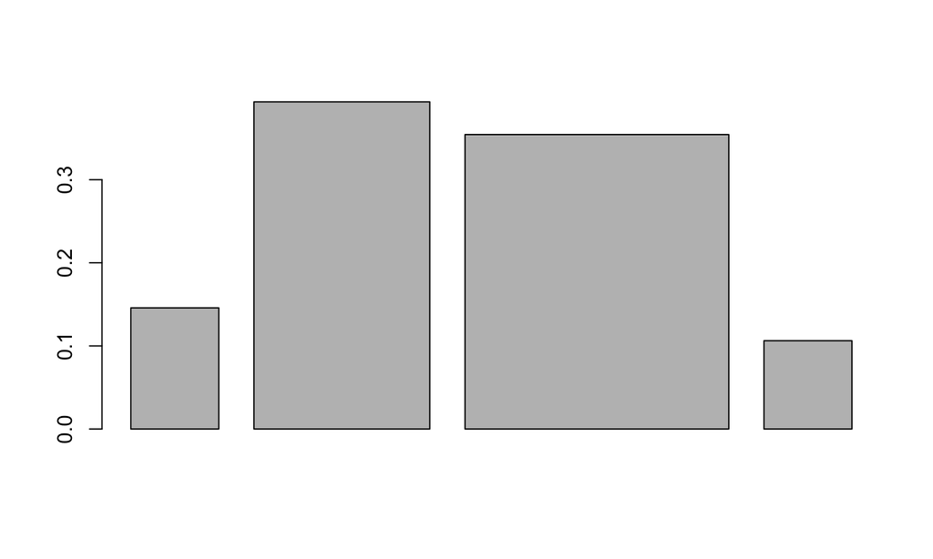

```r
x<-dbinom(0:3, size=3, prob=(18/38))
barplot(x, 1:3)
```